# Forecasting COE Supply 8-12 Quarters Ahead

DBA3702 group project: predictive-modelling workflow in R

DBA3702 Group Project

Data: LTA, Jan 2010 to Oct 2026

**Problem statement.** Can COE supply be forecast far enough ahead, and with honest uncertainty, for a dealer or fleet operator to price and time real financial exposure?

**How the analysis is built.**

| Step | What we do |
| --- | --- |
| Forecast contract | Use only information published up to the forecast month |
| Target | Monthly car deregistrations (Cat A + B), 1-36 months ahead |
| Baseline | quota.sg-style: rolling 12-month average carried forward |
| Evidence for the approach | Fig 02: correlation with COEs won *k* months earlier (the 10-year lag) |
| Features | Hypotheses H1-H8 turned into feature groups |
| Leakage test | Change the future; the features must not change |
| Validation | Rolling-origin backtest (expanding window) |
| Models | Rolling average, linear regression (cohort), Ridge, random forest |
| Selection rule | Simpler model unless the leader is better by > 2 SE and a practical threshold |
| Feature-group ablation | Remove each group in turn from the full linear model |
| Prediction intervals | Empirical forecast-error ratios by horizon |
| Uncertainty of the gain | Moving-block bootstrap; fan chart from whole error paths |
| Held-out test | Last 24 months of targets kept out of model selection |
| Decision outputs | 12-quarter quota fan chart and order-book exposure by timing shift |

## 0. Settings: everything the group may want to change is here

**What this section does.** Every choice the group might change (horizon, validation/test split, practical threshold, simulation count, example order book) lives here, so the whole analysis can be rerun with one edit. Two choices matter most: the **36-month horizon** matches the 8-12 quarter planning window dealers and fleet operators need (quota.sg stops at 3 quarters), and the **Aug 2024 split** keeps the last 24 months completely out of model selection.

```r
DATA_DIR   <- "data"
OUT_DIR    <- "outputs"
H_MAX      <- 36            # forecast horizon in months (12 quarters)
CV_START   <- "2019-01"     # first forecast origin in the backtest
VAL_END    <- "2024-08"     # targets up to here = validation; after = test (frozen)
PRACTICAL  <- 0.02          # a gain must be >= 2% of mean monthly deregs to count
COVID_CB   <- c("2020-04", "2020-05", "2020-06")   # bidding suspended
SEED       <- 3702
N_SIM      <- 2000          # simulated paths for the fan chart
PATH_FROM  <- "2020-07"     # error paths for the fan: origins after the 2020 suspension
                            # (earlier origins had < 4.5 years of training data)
C_RECENT_Q <- 4             # recent quarters used to sample LTA's "Part c" (one draw per path)
# Aug-Oct 2026 has only 5 of 6 exercises in the data; use LTA's announced quota
# (news release 24 Jul 2026: Cat A 7,134 + Cat B 5,527)
ANNOUNCED_AB <- c("2026-08" = 7134 + 5527)
ORDER_BOOK <- c(50, 50, 50, 50)   # cars the dealer must register in the next 4 quarters
dir.create(OUT_DIR, showWarnings = FALSE)
set.seed(SEED)

# Month index helpers: integer months make "10 years earlier" exact arithmetic
mi      <- function(ym) as.integer(substr(ym, 1, 4)) * 12L + as.integer(substr(ym, 6, 7)) - 1L
mi_ym   <- function(i) sprintf("%d-%02d", i %/% 12L, i %% 12L + 1L)
mi_date <- function(i) as.Date(paste0(mi_ym(i), "-01"))
find_file <- function(name) {
  f <- list.files(DATA_DIR, pattern = name, recursive = TRUE, full.names = TRUE)
  if (length(f) == 0) stop("Put ", name, " in ", DATA_DIR)
  f[1]
}
save_plot <- function(p, file, w = 10, h = 5) {
  ggsave(file.path(OUT_DIR, file), p, width = w, height = h, dpi = 150, bg = "white")
  print(p)                                       # show the figure in the notebook
}
```

## 1. Question and objective

- Decision supported: a dealer pricing a forward order book, or a fleet planning a replacement cycle, wants to know whether COE supply in each of the next 12 quarters will be high or low, and how sure we can be.
- Prediction task: at the end of month o (the origin), forecast car deregistrations (Cat A + B) for months o+1 … o+36, then turn them into quota using LTA’s formula (25% of the last 12 months’ deregistrations, plus adjustments “Part c”).
- Forecast contract: only information published up to month o.
- Success: (1) lower error than the quota.sg-style rolling average, at every horizon. and (2) prediction intervals whose stated coverage holds on the frozen test.
- Out of scope: forecasting premiums (they also depend on demand). Section 9 only shows the supply-driven part of premium risk.

## 2. Inspection and cleaning

**What this section does.** Loads the five LTA files, fixes known format problems and builds the three series the model uses: monthly car deregistrations (Cat A + B, the thing we forecast), monthly PQP (the renewal price) and the number of cars in each age band (the cohort pipeline).

**Why it matters.** Two traps are handled here rather than inside the model: bid counts stored as text with commas (“1,232”), and the oldest age band spelled two ways (“20 and above” / “20 & above”). Each file also ends in a different month, so everything is cut at the last month common to deregistrations and ages.

```r
results <- read_csv(find_file("M11-coe_results.csv"), col_types = cols(.default = "c")) %>%
  mutate(across(c(quota, bids_success, bids_received, premium), parse_number),  # "1,232" -> 1232
         bidding_no = as.integer(bidding_no), t = mi(month))
pqp     <- read_csv(find_file("M11-coe_results_pqp.csv"), show_col_types = FALSE) %>% mutate(t = mi(month))
dereg   <- read_csv(find_file("M05-Dereg_by_Quota.csv"), show_col_types = FALSE) %>% mutate(t = mi(month))
reval   <- read_csv(find_file("M10-Monthly_COE_Revalidation.csv"), show_col_types = FALSE) %>% mutate(t = mi(month))
age     <- read_csv(find_file("M01-03M-Age.csv"), show_col_types = FALSE) %>%
  mutate(t = mi(month),
         band = as.integer(parse_number(age)))   # "9 - < 10" -> 9; "20 and above" / "20 & above" -> 20

cat("\n== 2.1 Coverage ==\n")
```

```
== 2.1 Coverage ==
```

```r
for (nm in c("results", "pqp", "dereg", "reval", "age")) {
  d <- get(nm)
  cat(sprintf("%-8s %s to %s, %d rows\n", nm, mi_ym(min(d$t)), mi_ym(max(d$t)), nrow(d)))
}
```

```
results  2010-01 to 2026-10, 1985 rows
pqp      2010-02 to 2026-10, 804 rows
dereg    2014-01 to 2026-08, 912 rows
reval    2015-01 to 2026-07, 1112 rows
age      2016-01 to 2026-08, 10752 rows
```

```r
missing_results <- setdiff(seq(min(results$t), max(results$t)), unique(results$t))
cat("Months with no bidding:", mi_ym(missing_results), "\n")
```

```
Months with no bidding: 2020-04 2020-05 2020-06
```

```r
# Monthly series used throughout
y_tbl <- dereg %>% filter(category %in% c("Category A", "Category B")) %>%
  group_by(t) %>% summarise(y = sum(number), .groups = "drop")       # car deregs, A + B
pqp_tbl <- pqp %>% filter(vehicle_class %in% c("Category A", "Category B")) %>%
  group_by(t) %>% summarise(pqp = mean(pqp), .groups = "drop")
cars <- age %>% filter(type == "Cars") %>% select(t, band, number)
stopifnot(all(count(cars, t)$n == 21), !anyNA(cars$number))          # 21 bands, no gaps for cars

T_LAST <- min(max(y_tbl$t), max(cars$t))                             # common end: Aug 2026
cat("Modelling data end (common to dereg and age):", mi_ym(T_LAST), "\n")
```

```
Modelling data end (common to dereg and age): 2026-08
```

**Observations (2).**

- The five files cover 2010-2026 for prices, 2014-2026 for deregistrations and 2016-2026 for ages. The binding constraint is the **age data, which starts in January 2016**, so the model can learn from about ten years.
- Bidding was suspended in **April-June 2020**. These months are kept, with a flag (`cb`), because a business must plan for shocks too.
- All files are cut at **August 2026**, the last month present in both the deregistration and age data. Bidding results run to October 2026, but using them would mix information the model cannot have at the same time.

```r
# Stock matrix: rows = months, columns = age bands 0..20
S_mat <- cars %>% pivot_wider(names_from = band, values_from = number) %>% arrange(t)
T0 <- min(S_mat$t)
S_mat <- as.matrix(S_mat[, as.character(0:20)])
stock <- function(tt, b, S = S_mat) S[cbind(tt - T0 + 1L, b + 1L)]
```

## 3. Visualisation (EDA)

**What this section does.** Three charts test the project’s central claim before any model is built: is COE supply mechanical (decided years in advance by who registered when), and does the renewal price change it?

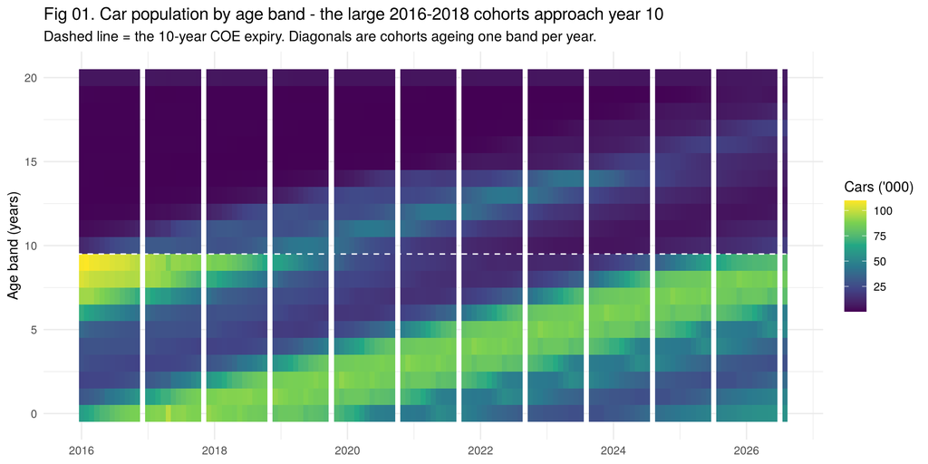

```r
# Fig 01 - the cohort wave: cars by age band over time
p01 <- cars %>% mutate(date = mi_date(t)) %>%
  ggplot(aes(date, band, fill = number / 1000)) + geom_raster() +
  scale_fill_viridis_c(name = "Cars ('000)") +
  geom_hline(yintercept = 9.5, colour = "white", linetype = "dashed") +
  labs(title = "Fig 01. Car population by age band - the large 2016-2018 cohorts approach year 10",
       subtitle = "Dashed line = the 10-year COE expiry. Diagonals are cohorts ageing one band per year.",
       x = NULL, y = "Age band (years)") + theme_minimal()
save_plot(p01, "fig01_cohort_wave.png")
```

**Observations (Fig 01).**

- Each diagonal is a registration cohort ageing one band per year. The bright band now sitting at **ages 7-10 holds about 239,000 cars** (77.7k, 83.7k and 77.3k in the three bands), against only about 19,000 cars aged 10-11.
- These are the large 2016-2018 cohorts. They reach their 10-year decision (renew or scrap) between **2026 and 2029**, which is the supply wave the forecast must capture.
- Ages 2-4 are thin (about 27-38k per band), reflecting the tight quotas of 2022-23, so a **supply trough should follow around 2032-34**.
- **Why it matters:** most of the next three years’ supply is already parked on the road, visible in public data today. A fleet planning a replacement cycle is choosing between landing in this wave or in the trough after it.

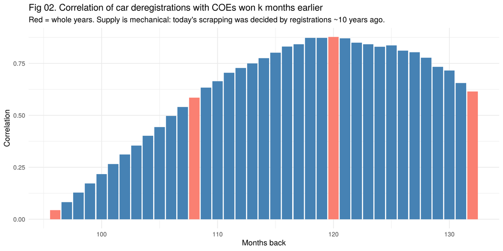

```r
# Fig 02 - which past month best predicts today's deregistrations?
reg_tbl <- results %>% filter(vehicle_class %in% c("Category A", "Category B")) %>%
  group_by(t) %>% summarise(reg = sum(bids_success), .groups = "drop")   # registrations proxy
lag_corr <- map_dfr(seq(96, 132, 1), function(k) {
  d <- y_tbl %>% inner_join(reg_tbl %>% mutate(t = t + k), by = "t")
  tibble(months_back = k, correlation = cor(d$y, d$reg), pairs = nrow(d))
})
p02 <- ggplot(lag_corr, aes(months_back, correlation, fill = months_back %% 12 == 0)) +
  geom_col() + scale_fill_manual(values = c("steelblue", "salmon"), guide = "none") +
  labs(title = "Fig 02. Correlation of car deregistrations with COEs won k months earlier",
       subtitle = "Red = whole years. Supply is mechanical: today's scrapping was decided by registrations ~10 years ago.",
       x = "Months back", y = "Correlation") + theme_minimal()
save_plot(p02, "fig02_lag_correlation.png")
```

```r
cat("\n== 3. Strongest lag:", lag_corr$months_back[which.max(lag_corr$correlation)],
    "months, r =", round(max(lag_corr$correlation), 3), "\n")
```

```
== 3. Strongest lag: 120 months, r = 0.877
```

**Observations (Fig 02).**

- Car deregistrations correlate most strongly with COEs won **exactly 120 months earlier (r = 0.88)**, the 10-year COE life. A year either side (108 or 132 months) the correlation falls to about 0.6.
- **Why it matters:** this is the evidence that supply is substantially mechanical. A rolling average of recent deregistrations (quota.sg’s method) ignores this signal; a cohort model uses it directly.

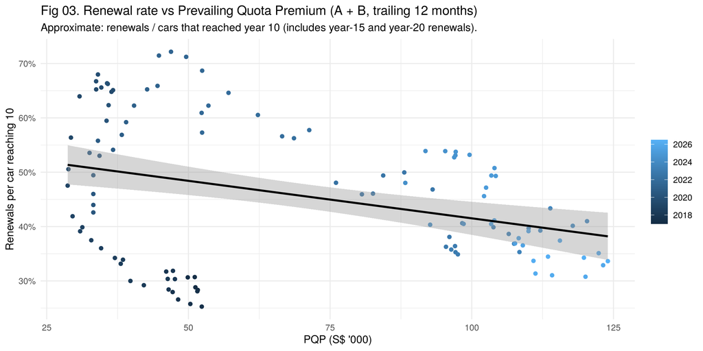

```r
# Fig 03 - the feedback loop: renewal rate vs PQP (rolling 12 months)
renew_tbl <- reval %>% filter(category %in% c("Category A", "Category B")) %>%
  group_by(t) %>% summarise(renewals = sum(number), .groups = "drop") %>%
  arrange(t) %>%
  mutate(renew12 = stats::filter(renewals, rep(1, 12), sides = 1)) %>%  # trailing 12-month sum
  filter(t - 12 >= T0, t <= max(cars$t)) %>%
  mutate(due12 = stock(t - 12, 9),               # cars that were 9-10 a year ago = reached 10 since
         renew_rate = as.numeric(renew12) / due12) %>%
  left_join(pqp_tbl, by = "t") %>% filter(!is.na(renew_rate))
p03 <- ggplot(renew_tbl, aes(pqp / 1000, renew_rate, colour = mi_date(t))) +
  geom_point() + geom_smooth(method = "lm", se = TRUE, colour = "black", formula = y ~ x) +
  scale_colour_date(name = NULL) + scale_y_continuous(labels = percent) +
  labs(title = "Fig 03. Renewal rate vs Prevailing Quota Premium (A + B, trailing 12 months)",
       subtitle = "Approximate: renewals / cars that reached year 10 (includes year-15 and year-20 renewals).",
       x = "PQP (S$ '000)", y = "Renewals per car reaching 10") + theme_minimal()
save_plot(p03, "fig03_feedback.png")
```

```r
cat("Correlation renewal rate vs PQP:", round(cor(renew_tbl$renew_rate, renew_tbl$pqp), 3), "\n")
```

```
Correlation renewal rate vs PQP: -0.349
```

**Observations (Fig 03).**

- Taken on its own, the renewal rate is **lower** when PQP is high (r = -0.35), the opposite of the simple feedback story.
- This raw chart is **confounded by time**. The denominator (cars reaching year 10) grew sharply from 2024 as the big 2016-18 cohorts arrived, while PQP rose over the same years. Renewals did rise in absolute terms (26,770 in 2024 to 32,783 in 2025), but not as fast as the cohort.
- The model in sections 6-7 separates the two effects. Holding cohort size fixed, higher PQP **does** mean fewer year-10 cars are scrapped (the negative `due10 x lpqp` coefficient in section 7).
- **Why it matters:** a raw scatter would mislead an audience. The feedback loop exists, but it only shows once the cohort wave is accounted for.

## 4. Hypotheses -> feature groups

| # | Hypothesis | Evidence | Becomes |
| --- | --- | --- | --- |
| H1 | Cars reaching year 10 drive deregistrations | Fig 01, 02 | `due10` |
| H2 | Cars on 5-year renewals must leave at year 15 | Revalidation data | `due15` |
| H3 | Cars on 10-year renewals decide again at year 20 | Revalidation data | `due20` |
| H4 | High PQP makes owners renew instead of scrapping | Fig 03 | `lpqp`, `due10 x lpqp` |
| H5 | Deregistrations have a calendar pattern | - | month of year |
| H6 | Recent level carries extra information | - | `recent12` |
| H7 | Nonlinear effects beyond these | - | random forest |
| H8 | Many coefficients may overfit | - | Ridge |

## 5. Features - built only from data up to the origin month o

**What this section does.** Turns the age table into forecast inputs. For any forecast month and horizon (1-36 months ahead), it counts the cars that will reach year 10, 15 or 20 in that month, using only data available at the forecast date. It adds the PQP at that date, the recent 12-month level, the calendar month and the 2020 flag.

**Why it matters.** A forecast that accidentally uses future information looks excellent in a backtest and fails in real use. The **leakage test** below triples every number after the forecast date and checks that no feature changes; the script stops if one does.

A car in age band *b* at month *o* reaches age *b + 1* within the next 12 months. So cars due at year 10 in months *o + 1 … o + 12* sit in band 9 at *o*; for *o + 13 … o + 24* they sit in band 8 (and must survive one more year), and so on. Survival between bands is estimated only from age snapshots seen by *o*.

```r
survival_at <- function(o, S = S_mat) {
  # one-year survival ratio band b -> b+1, using pairs (t, t+12) with t+12 <= o
  if (o - 12L < T0) return(rep(1, 20))           # first year: no pairs yet, assume no losses
  ts <- T0:(o - 12L)
  sapply(0:19, function(b) min(1, mean(S[ts + 12L - T0 + 1L, b + 2L] / S[ts - T0 + 1L, b + 1L])))
}

build_features <- function(o, h = 1:H_MAX, S = S_mat, y = y_tbl, pq = pqp_tbl) {
  sv <- survival_at(o, S)
  k  <- (h - 1L) %/% 12L                         # whole years ahead
  surv_to <- function(from, to) sapply(from, function(f) if (f > to) 1 else prod(sv[(f:to) + 1L]))
  b10 <- 9L - k; b15 <- 14L - k; b20 <- 19L - k
  tibble(
    origin = o, h = h, t = o + h,
    due10  = stock(o, b10, S) * surv_to(b10, 8L) / 12,
    due15  = stock(o, b15, S) * surv_to(b15, 13L) / 12,
    due20  = stock(o, b20, S) * surv_to(b20, 18L) / 12,
    lpqp   = log(pq$pqp[pq$t == o] / 50000),     # centred at S$50k
    recent12 = mean(y$y[y$t > o - 12L & y$t <= o]),
    moy    = factor((o + h) %% 12L + 1L, levels = 1:12),
    cb     = as.integer(mi_ym(o + h) %in% COVID_CB)   # calendar fact, known in advance
  )
}

# Leakage test: changing anything after the
# origin must not change the features.
o_test <- mi("2022-06")
f1 <- build_features(o_test)
S_fake <- S_mat; future_rows <- which((T0:(T0 + nrow(S_mat) - 1L)) > o_test); S_fake[future_rows, ] <- S_fake[future_rows, ] * 3
y_fake <- y_tbl %>% mutate(y = if_else(t > o_test, y * 3, y))
p_fake <- pqp_tbl %>% mutate(pqp = if_else(t > o_test, pqp * 3, pqp))
f2 <- build_features(o_test, S = S_fake, y = y_fake, pq = p_fake)
stopifnot(isTRUE(all.equal(f1, f2)))
cat("\n== 5. Leakage test passed: features ignore everything after the origin ==\n")
```

```
== 5. Leakage test passed: features ignore everything after the origin ==
```

```r
# Panel of (origin, horizon) rows, every origin with stock and 12 months of history
panel <- map_dfr(max(T0, min(y_tbl$t) + 11L):(T_LAST - 1L), build_features) %>%
  left_join(y_tbl, by = "t")                     # y is NA beyond T_LAST
cat("Panel rows:", nrow(panel), "| with known target:", sum(!is.na(panel$y)), "\n")
```

```
Panel rows: 4572 | with known target: 3942
```

**Observations (5).**

- The leakage test passes: features depend only on information available at the forecast date.
- The panel has 4,572 (forecast date x horizon) rows, 3,942 of which have a known outcome to learn from or score against.

## 6. Modelling

**What this section does.** Competes seven models on equal terms, from the quota.sg-style rolling average up to a random forest. Every model is refitted at each forecast date from January 2019 using only data up to that date, then forecasts the next 36 months. This **rolling-origin backtest** is the honest way to score a time-series forecast, because it reproduces how the tool would have performed if used live.

**Why it matters.** The business claim is “we forecast further ahead and better than the existing tool”. This section is where that claim is tested, with a selection rule fixed before looking at the test period.

```r
FORMULAS <- list(
  cohort   = y ~ due10 + due15 + due20,
  feedback = y ~ due10 + due15 + due20 + lpqp + due10:lpqp,
  full     = y ~ due10 + due15 + due20 + lpqp + due10:lpqp + moy + recent12 + cb,
  # lean = groups the ablation in 6.3 found helpful (set after the ablation)
  lean     = y ~ due10 + lpqp + due10:lpqp + moy + cb
)
MODELS <- tibble(
  model      = c("Rolling average (quota.sg-style)", "Linear | cohort", "Linear | cohort + feedback",
                 "Linear | lean", "Linear | full", "Ridge | full", "Random forest | full"),
  complexity = c(0, 1, 2, 2.5, 3, 4, 5)
)

fit_predict <- function(train, test, which = MODELS$model) {
  out <- tibble(.rows = nrow(test))
  if ("Rolling average (quota.sg-style)" %in% which) out[["Rolling average (quota.sg-style)"]] <- test$recent12
  if ("Linear | cohort" %in% which) out[["Linear | cohort"]] <- predict(lm(FORMULAS$cohort, train), test)
  if ("Linear | cohort + feedback" %in% which) out[["Linear | cohort + feedback"]] <- predict(lm(FORMULAS$feedback, train), test)
  if ("Linear | lean" %in% which) out[["Linear | lean"]] <- predict(lm(FORMULAS$lean, train), test)
  if ("Linear | full" %in% which) out[["Linear | full"]] <- predict(lm(FORMULAS$full, train), test)
  if ("Ridge | full" %in% which) {
    X  <- model.matrix(FORMULAS$full, train)[, -1]
    Xt <- model.matrix(update(FORMULAS$full, NULL ~ .), test)[, -1]
    cv <- cv.glmnet(X, train$y, alpha = 0, nfolds = 5)
    out[["Ridge | full"]] <- as.numeric(predict(cv, Xt, s = "lambda.1se"))
  }
  if ("Random forest | full" %in% which) {
    rf <- ranger(y ~ due10 + due15 + due20 + lpqp + moy + recent12 + cb, data = train,
                 num.trees = 300, min.node.size = 20, seed = SEED)
    out[["Random forest | full"]] <- predict(rf, test)$predictions
  }
  # deregistrations cannot be negative or collapse to nothing: floor at 20% of the recent level
  out %>% mutate(across(everything(), ~ pmax(.x, 0.2 * test$recent12)))
}
```

### 6.1 Rolling-origin backtest (expanding window)

For origin o: train on rows whose target month <= o, predict o+1..o+36.

```r
run_backtest <- function(formulas_override = NULL, which = MODELS$model, origins = mi(CV_START):(T_LAST - 1L)) {
  if (!is.null(formulas_override)) { old <- FORMULAS; FORMULAS <<- formulas_override; on.exit(FORMULAS <<- old) }
  suppressWarnings(map_dfr(origins, function(o) {   # early origins: rank-deficient fits warn
    train <- panel %>% filter(t <= o, !is.na(y))
    test  <- panel %>% filter(origin == o, !is.na(y))
    if (nrow(test) == 0) return(NULL)
    bind_cols(test %>% select(origin, h, t, y), fit_predict(train, test, which)) %>%
      pivot_longer(-c(origin, h, t, y), names_to = "model", values_to = "pred")
  }))
}
cat("\n== 6.1 Running rolling-origin backtest ... ==\n")
```

```
== 6.1 Running rolling-origin backtest ... ==
```

```r
bt <- run_backtest() %>%
  mutate(window = if_else(t <= mi(VAL_END), "validation", "test"),
         hq = ceiling(h / 3), horizon = cut(hq, c(0, 4, 8, 12), labels = c("Q1-4", "Q5-8", "Q9-12")),
         err = pred - y, abs_err = abs(err))

hourly_like <- bt %>% filter(window == "validation") %>%
  group_by(model, horizon) %>% summarise(MAE = mean(abs_err), .groups = "drop") %>%
  pivot_wider(names_from = horizon, values_from = MAE) %>%
  left_join(bt %>% filter(window == "validation") %>% group_by(model) %>%
              summarise(MAE_all = mean(abs_err), bias = mean(err)), by = "model") %>%
  left_join(MODELS, by = "model") %>% arrange(MAE_all)
cat("\nValidation MAE (cars per month), by horizon:\n"); print(hourly_like, width = 200)
```

```
Validation MAE (cars per month), by horizon:
```

```
# A tibble: 7 x 7
  model                            `Q1-4` `Q5-8` `Q9-12` MAE_all   bias complexity
  <chr>                             <dbl>  <dbl>   <dbl>   <dbl>  <dbl>      <dbl>
1 Linear | lean                      578.   759.    961.    735.  301.         2.5
2 Linear | cohort                    559.   898.    859.    748.   33.2        1
3 Ridge | full                       633.   864.    784.    748. -268.         4
4 Linear | cohort + feedback         554.   939.    930.    777.   79.4        2
5 Linear | full                      727.  1238.   1256.   1031.  327.         3
6 Random forest | full               778.  1273.   1674.   1169.  962.         5
7 Rolling average (quota.sg-style)   926.  1410.   1829.   1316. 1055.         0
```

### 6.2 Selection rule

rank by pooled validation MAE; prefer the simpler model unless the leader beats it by > 2 SE (paired by origin) AND >= PRACTICAL.

```r
paired_gain <- function(a, b, win = "validation", d = bt) {
  # positive = model a has lower error than model b
  x <- d %>% filter(window == win, model %in% c(a, b)) %>%
    group_by(origin, model) %>% summarise(mae = mean(abs_err), .groups = "drop") %>%
    pivot_wider(names_from = model, values_from = mae) %>% na.omit()
  g <- x[[b]] - x[[a]]
  tibble(a = a, b = b, mean_gain = mean(g), se = sd(g) / sqrt(length(g)),
         origins_better = sum(g > 0), origins = length(g))
}
threshold <- PRACTICAL * mean(y_tbl$y[y_tbl$t <= mi(VAL_END)])
leader <- hourly_like$model[1]
sel_tbl <- map_dfr(setdiff(MODELS$model, leader), ~ paired_gain(leader, .x)) %>%
  mutate(clearly_better = mean_gain > 2 * se & mean_gain >= threshold)
cat(sprintf("\nLeader: %s. Practical threshold: %.0f cars/month\n", leader, threshold))
```

```
Leader: Linear | lean. Practical threshold: 88 cars/month
```

```r
print(sel_tbl, width = 200)
```

```
# A tibble: 6 x 7
  a             b                                mean_gain    se origins_better origins clearly_better
  <chr>         <chr>                                <dbl> <dbl>          <int>   <int> <lgl>
1 Linear | lean Rolling average (quota.sg-style)    427.    68.9             53      67 TRUE
2 Linear | lean Linear | cohort                       9.63  47.0             29      67 FALSE
3 Linear | lean Linear | cohort + feedback           23.9   51.0             31      67 FALSE
4 Linear | lean Linear | full                       235.    76.1             52      67 TRUE
5 Linear | lean Ridge | full                         62.3   48.6             49      67 FALSE
6 Linear | lean Random forest | full                308.    56.2             44      67 TRUE
```

```r
not_beaten <- c(leader, sel_tbl$b[!sel_tbl$clearly_better])
SELECTED <- MODELS %>% filter(model %in% not_beaten) %>% arrange(complexity) %>% slice(1) %>% pull(model)
cat("SELECTED:", SELECTED, "\n")
```

```
SELECTED: Linear | cohort
```

**Observations (6.2).**

- **Linear | lean** has the lowest validation error, but it beats the simpler **Linear | cohort** by only 10 cars a month (SE 47), far below the 88-car practical threshold.
- Under the rule, the simplest model the leader does not clearly beat is chosen: **Linear | cohort**, which uses only cars reaching years 10, 15 and 20.
- **Why it matters:** the chosen model is easy to explain on one slide (“count the cars coming due”), which builds trust with a dealer audience.

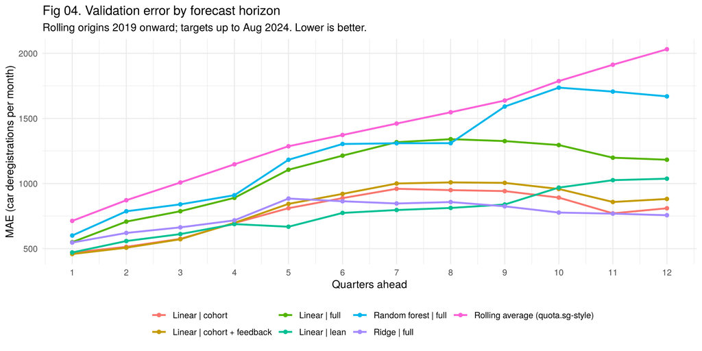

```r
p04 <- bt %>% filter(window == "validation") %>% group_by(model, hq) %>%
  summarise(MAE = mean(abs_err), .groups = "drop") %>%
  ggplot(aes(hq, MAE, colour = model)) + geom_line(linewidth = 0.9) + geom_point() +
  scale_x_continuous(breaks = 1:12) +
  labs(title = "Fig 04. Validation error by forecast horizon",
       subtitle = "Rolling origins 2019 onward; targets up to Aug 2024. Lower is better.",
       x = "Quarters ahead", y = "MAE (car deregistrations per month)", colour = NULL) +
  theme_minimal() + theme(legend.position = "bottom")
save_plot(p04, "fig04_mae_by_horizon.png")
```

**Observations (Fig 04).** The gap between the rolling average (top line) and the cohort models widens with horizon. That is exactly the 8-12 quarter window where dealers and fleets lack tools today, and where our approach adds the most.

### 6.3 Feature-group ablation on the full linear model

**What this section does.** Removes each feature group in turn from the full linear model and measures how much the error changes. A group whose removal makes the forecast *better* is not earning its place.

```r
cat("\n== 6.3 Ablation: remove one group at a time from Linear | full ==\n")
```

```
== 6.3 Ablation: remove one group at a time from Linear | full ==
```

```r
full_terms <- c("due10", "due15", "due20", "lpqp", "due10:lpqp", "moy", "recent12", "cb")
groups <- list("year-10 cohort (H1)" = "due10", "year-15 expiries (H2)" = "due15",
               "year-20 decisions (H3)" = "due20", "PQP feedback (H4)" = c("lpqp", "due10:lpqp"),
               "month of year (H5)" = "moy", "recent level (H6)" = "recent12")
abl <- map_dfr(names(groups), function(g) {
  keep <- setdiff(full_terms, groups[[g]])
  if (g == "year-10 cohort (H1)") keep <- setdiff(keep, "due10:lpqp")
  f <- reformulate(keep, "y")
  b <- run_backtest(modifyList(FORMULAS, list(full = f)), which = "Linear | full") %>%
    mutate(window = if_else(t <= mi(VAL_END), "validation", "test"), abs_err = abs(pred - y),
           model = "without")
  both <- bind_rows(bt %>% filter(model == "Linear | full") %>% select(origin, h, t, window, model, abs_err),
                    b %>% select(origin, h, t, window, model, abs_err))
  paired_gain("Linear | full", "without", d = both) %>% transmute(removed = g, MAE_increase_when_removed = mean_gain, se)
})
print(abl, width = 200)
```

```
# A tibble: 6 x 3
  removed                MAE_increase_when_removed    se
  <chr>                                      <dbl> <dbl>
1 year-10 cohort (H1)                       241.   63.9
2 year-15 expiries (H2)                    -183.   71.8
3 year-20 decisions (H3)                     40.7  55.0
4 PQP feedback (H4)                          -7.75  7.03
5 month of year (H5)                         20.3  19.7
6 recent level (H6)                         -82.2  13.4
```

## 7. Diagnostics and what the model learned

**What this section does.** Fits the full model on all data to read what it has learned, and checks whether the chosen model is systematically too high or too low in any year.

```r
final_lm <- lm(FORMULAS$full, panel %>% filter(!is.na(y)))
cat("\n== 7. Coefficients, Linear | full fitted on all data ==\n")
```

```
== 7. Coefficients, Linear | full fitted on all data ==
```

```r
print(round(summary(final_lm)$coefficients[c("due10", "due15", "due20", "lpqp", "due10:lpqp", "recent12", "cb"), ], 3))
```

```
           Estimate Std. Error t value Pr(>|t|)
due10         0.640      0.010  67.133    0.000
due15         0.073      0.024   2.997    0.003
due20         1.156      0.200   5.785    0.000
lpqp        430.307     58.835   7.314    0.000
due10:lpqp   -0.123      0.018  -6.717    0.000
recent12     -0.044      0.011  -3.906    0.000
cb         -841.107     56.169 -14.975    0.000
```

```r
cat("Reading: due10 = share of cars reaching year 10 that are scrapped in that month;",
    "a negative due10:lpqp means higher PQP -> fewer of them scrapped (the feedback loop).\n")
```

```
Reading: due10 = share of cars reaching year 10 that are scrapped in that month; a negative due10:lpqp means higher PQP -> fewer of them scrapped (the feedback loop).
```

**Observations (7).**

- **`due10` = 0.64:** at a PQP of S$50,000 (where `lpqp` = 0), about 64 of every 100 cars reaching year 10 are deregistered. At today’s PQP of about S$120,000 the model puts it nearer 53, because of the feedback term below.
- **The feedback loop is real:** the `due10 x lpqp` term is negative and highly significant (t = -6.7). At today’s cohort sizes, a 10% rise in PQP means roughly 35 fewer deregistrations a month, and therefore less future quota.
- **The 2020 suspension** cut deregistrations by about 840 cars a month while it lasted.
- **Bias by year:** the chosen model under-forecast 2020-21 (COVID) and over-forecast 2019 and 2022, but is within about 100-200 cars a month in 2023-24. Errors are largest around the pandemic, which is why the fan chart in 9.1 drops paths that start before July 2020.

```r
sel_res <- bt %>% filter(model == SELECTED, window == "validation")
cat("Selected-model bias by year of target (validation):\n")
```

```
Selected-model bias by year of target (validation):
```

```r
print(sel_res %>% group_by(year = t %/% 12L) %>% summarise(bias = mean(err), MAE = mean(abs_err)))
```

```
# A tibble: 6 x 3
   year  bias   MAE
  <int> <dbl> <dbl>
1  2019  434.  750.
2  2020 -243.  912.
3  2021 -341. 1012.
4  2022  494.  830.
5  2023  100.  474.
6  2024 -189.  590.
```

## 8. Evaluation on the frozen test (targets Sep 2024 - Aug 2026)

**What this section does.** Scores every model on the last 24 months (September 2024 - August 2026), which played no part in choosing the model. This is the evidence to show in the deck.

```r
test_tbl <- bt %>% filter(window == "test") %>% group_by(model, horizon) %>%
  summarise(MAE = mean(abs_err), .groups = "drop") %>%
  pivot_wider(names_from = horizon, values_from = MAE) %>%
  left_join(bt %>% filter(window == "test") %>% group_by(model) %>% summarise(MAE_all = mean(abs_err)), by = "model") %>%
  arrange(MAE_all)
cat("\n== 8. Test MAE (frozen) ==\n"); print(test_tbl, width = 200)
```

```
== 8. Test MAE (frozen) ==
```

```
# A tibble: 7 x 5
  model                            `Q1-4` `Q5-8` `Q9-12` MAE_all
  <chr>                             <dbl>  <dbl>   <dbl>   <dbl>
1 Linear | lean                      491.   655.    808.    651.
2 Random forest | full               824.   890.    897.    871.
3 Linear | cohort + feedback         526.  1243.   1265.   1011.
4 Linear | cohort                    527.  1359.   1412.   1099.
5 Linear | full                      496.  1467.   1626.   1196.
6 Rolling average (quota.sg-style)  1165.  1896.   2170.   1744.
7 Ridge | full                       659.  2683.   2756.   2033.
```

**Observations (8).**

- **The chosen cohort model cuts error by 37% against the rolling average** on the test (1,099 vs 1,744 cars a month), and it is better at every horizon.
- **Linear | lean does best on the test (651)**, 41% better than the chosen model. It narrowly missed selection on validation, so the selection is **not** changed after the fact; it is reported as a candidate improvement rather than adopted.
- **Ridge collapses at longer horizons** (2,683 at 5-8 quarters), a reminder that the more complex models are not reliably better here.

### 8.1 Prediction intervals

empirical error ratios by horizon year (calibrated on validation), coverage checked on test - the COE version of “calibration”.

```r
ratios <- bt %>% filter(model == SELECTED) %>% mutate(ratio = y / pred, year_ahead = (h - 1) %/% 12 + 1)
bands <- ratios %>% filter(window == "validation") %>% group_by(year_ahead) %>%
  summarise(lo80 = quantile(ratio, .10), hi80 = quantile(ratio, .90),
            lo95 = quantile(ratio, .025), hi95 = quantile(ratio, .975), .groups = "drop")
coverage <- ratios %>% filter(window == "test") %>% left_join(bands, by = "year_ahead") %>%
  group_by(year_ahead) %>% summarise(covered80 = mean(ratio >= lo80 & ratio <= hi80),
                                     covered95 = mean(ratio >= lo95 & ratio <= hi95), n = n())
cat("\n8.1 Interval multipliers (validation) and coverage on test:\n"); print(bands); print(coverage)
```

```
8.1 Interval multipliers (validation) and coverage on test:
```

```
# A tibble: 3 x 5
  year_ahead  lo80  hi80  lo95  hi95
       <dbl> <dbl> <dbl> <dbl> <dbl>
1          1 0.717  1.29 0.626  1.45
2          2 0.618  2.54 0.534  3.12
3          3 0.539  2.08 0.418  2.80
```

```
# A tibble: 3 x 4
  year_ahead covered80 covered95     n
       <dbl>     <dbl>     <dbl> <int>
1          1     0.986     1       288
2          2     0.906     0.972   288
3          3     0.962     1       288
```

**Observations (8.1).** The intervals come from the ratio of actual to forecast in validation, separately for 1, 2 and 3 years ahead.

- The bands widen with horizon (80% range of about +/-29% one year ahead, wider beyond), which is the honest shape for a fan chart.
- **On the test they are conservative**: the 80% band contained 91-99% of outcomes. Validation included the COVID period, which inflates the bands.
- **Why it matters:** for a dealer, a band that is slightly too wide is safer than one that is too narrow. Report this openly as a calibration finding, as the proposal promised.

### 8.2 How certain is the gain over the rolling average

Moving-block bootstrap over consecutive origins (origins overlap, so they are not independent).

```r
block_boot <- function(a, b, win = "test", block = 6, B = 2000) {
  x <- bt %>% filter(window == win, model %in% c(a, b)) %>%
    group_by(origin, model) %>% summarise(mae = mean(abs_err), .groups = "drop") %>%
    pivot_wider(names_from = model, values_from = mae) %>% na.omit() %>% arrange(origin)
  n <- nrow(x); starts <- 1:(n - block + 1)
  gains <- replicate(B, {
    idx <- unlist(lapply(sample(starts, ceiling(n / block), replace = TRUE), function(s) s:(s + block - 1)))[1:n]
    1 - mean(x[[a]][idx]) / mean(x[[b]][idx])
  })
  tibble(a = a, vs = b, block = block, gain_pct = 100 * (1 - mean(x[[a]]) / mean(x[[b]])),
         lo95 = 100 * quantile(gains, .025), hi95 = 100 * quantile(gains, .975))
}
cat("\n8.2 Error reduction vs rolling average, test, moving-block bootstrap:\n")
```

```
8.2 Error reduction vs rolling average, test, moving-block bootstrap:
```

```r
print(map_dfr(c(3, 6, 12), ~ block_boot(SELECTED, "Rolling average (quota.sg-style)", block = .x)))
```

```
# A tibble: 3 x 6
  a               vs                               block gain_pct  lo95  hi95
  <chr>           <chr>                            <dbl>    <dbl> <dbl> <dbl>
1 Linear | cohort Rolling average (quota.sg-style)     3     39.1  29.3  49.6
2 Linear | cohort Rolling average (quota.sg-style)     6     39.1  25.8  52.8
3 Linear | cohort Rolling average (quota.sg-style)    12     39.1  23.4  55.0
```

**Observations (8.2).** Consecutive forecast dates overlap, so they are resampled in blocks.

- The chosen model reduces error by **39% against the quota.sg-style method (95% interval 23-55%)**, and the interval stays well above zero for 3, 6 and 12-month blocks.
- **Why it matters:** this is the headline competitive claim, and it is statistically secure, not a lucky period.

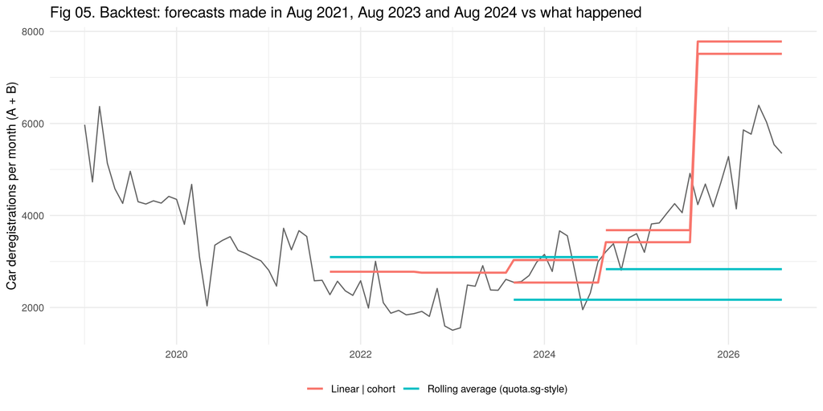

```r
p05 <- bt %>% filter(model %in% c(SELECTED, "Rolling average (quota.sg-style)"),
                     origin %in% mi(c("2021-08", "2023-08", "2024-08"))) %>%
  ggplot(aes(mi_date(t))) +
  geom_line(data = y_tbl %>% filter(t >= mi("2019-01")), aes(mi_date(t), y), colour = "grey40") +
  geom_line(aes(y = pred, colour = model, group = interaction(model, origin)), linewidth = 0.9) +
  labs(title = "Fig 05. Backtest: forecasts made in Aug 2021, Aug 2023 and Aug 2024 vs what happened",
       x = NULL, y = "Car deregistrations per month (A + B)", colour = NULL) +
  theme_minimal() + theme(legend.position = "bottom")
save_plot(p05, "fig05_backtest_paths.png")
```

**Observations (Fig 05).**

- Forecasts made in August 2021, 2023 and 2024 are compared with what happened (grey). The cohort model anticipates the 2025-26 rise in deregistrations (the forecast made in August 2024 overshoots it, as more owners renewed than in the past); the rolling average stays flat and misses the rise entirely.
- The cohort forecast moves in **yearly steps** because age bands are one year wide. A future improvement is to use monthly registrations (from bidding results) to give a smoother monthly shape.

## 9. Communication and decision

**What this section does.** Turns the validated model into the three outputs the business needs: a deregistration forecast with uncertainty, a quota projection for the next 12 quarters, and the COE cost of a dealer’s order book under different purchase timings.

### 9.1 Final forecast from the latest origin, with simulated paths

Each path re-uses a whole historical error path (all 36 horizons from one origin), so errors stay correlated across horizons - a bootstrap over origins.

```r
o_now <- T_LAST
train_all <- panel %>% filter(!is.na(y))
f_now <- build_features(o_now)
f_now$pred <- fit_predict(train_all, f_now, SELECTED)[[SELECTED]]
path_matrix <- function(from) {
  ratios %>% filter(origin >= mi(from)) %>% group_by(origin) %>% filter(n() == H_MAX) %>% ungroup() %>%
    select(origin, h, ratio) %>% pivot_wider(names_from = h, values_from = ratio) %>%
    select(as.character(1:H_MAX)) %>% as.matrix()
}
R <- path_matrix(PATH_FROM)
R_all <- path_matrix(CV_START)                       # sensitivity: every origin, incl. 2019-20
cat(sprintf("\n== 9.1 Forecast from %s using %d complete historical error paths ==\n", mi_ym(o_now), nrow(R)))
```

```
== 9.1 Forecast from 2026-08 using 38 complete historical error paths ==
```

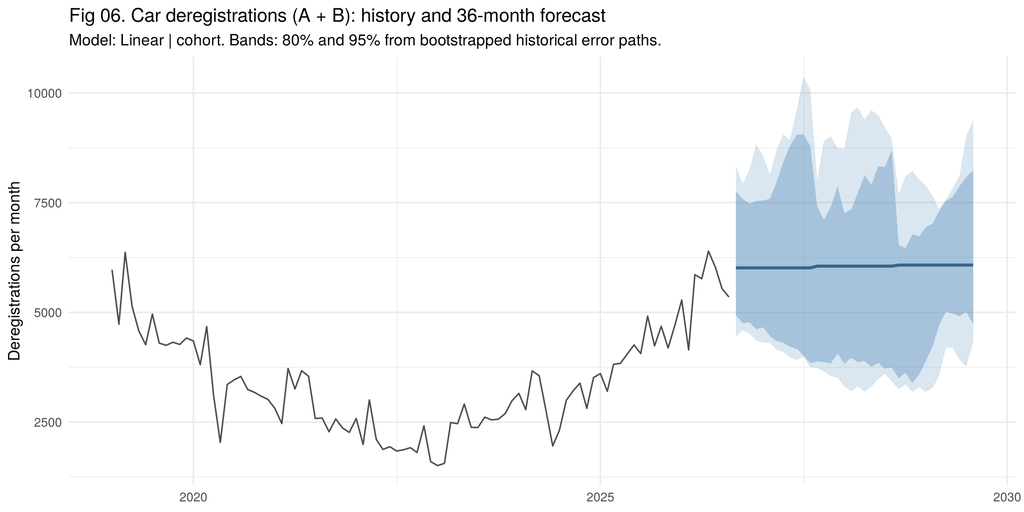

```r
sim_from <- function(Rm) Rm[sample(nrow(Rm), N_SIM, replace = TRUE), ] * matrix(f_now$pred, N_SIM, H_MAX, byrow = TRUE)
sim_y <- sim_from(R)

fan_m <- tibble(t = f_now$t, central = f_now$pred,
                lo80 = apply(sim_y, 2, quantile, .10), hi80 = apply(sim_y, 2, quantile, .90),
                lo95 = apply(sim_y, 2, quantile, .025), hi95 = apply(sim_y, 2, quantile, .975))
p06 <- ggplot(fan_m, aes(mi_date(t))) +
  geom_ribbon(aes(ymin = lo95, ymax = hi95), fill = "steelblue", alpha = .2) +
  geom_ribbon(aes(ymin = lo80, ymax = hi80), fill = "steelblue", alpha = .35) +
  geom_line(aes(y = central), colour = "steelblue4", linewidth = 1) +
  geom_line(data = y_tbl %>% filter(t >= mi("2019-01")), aes(mi_date(t), y), colour = "grey30") +
  labs(title = "Fig 06. Car deregistrations (A + B): history and 36-month forecast",
       subtitle = paste0("Model: ", SELECTED, ". Bands: 80% and 95% from bootstrapped historical error paths."),
       x = NULL, y = "Deregistrations per month") + theme_minimal()
save_plot(p06, "fig06_dereg_fan.png")
```

**Observations (Fig 06).**

- The model expects about **6,000 car deregistrations a month, roughly 72,000 a year through 2027-28**, up from about 62,000 over the last 12 months, as the 2016-2018 cohorts reach year 10.
- The 80% band is built from 38 complete historical error paths. Reusing whole paths keeps a bad year bad, so the band reflects realistic runs of over- or under-forecasting, not independent monthly noise.

### 9.2 From deregistrations to quota

Quota for the quarter starting qs = c * 25% * deregistrations over months qs-13 .. qs-2 (LTA’s formula, Part a) where c captures Part c (injections, cut-and-fill, expired TCOEs, Cat E share).

```r
quota_hist <- results %>% filter(vehicle_class %in% c("Category A", "Category B")) %>%
  mutate(qs = t - ((t %% 12L) - 1L) %% 3L) %>%           # quarter starts: Feb, May, Aug, Nov
  group_by(qs) %>% summarise(quota = sum(quota), exercises = n_distinct(paste(t, bidding_no)), .groups = "drop") %>%
  mutate(quota = if_else(mi_ym(qs) %in% names(ANNOUNCED_AB), unname(ANNOUNCED_AB[mi_ym(qs)]), quota),
         exercises = if_else(mi_ym(qs) %in% names(ANNOUNCED_AB), 6L, exercises)) %>%
  filter(exercises == 6)                               # complete quarters only (drops 2020 suspension)
window_sum <- function(qs, yv) sapply(qs, function(q) { w <- yv[as.character((q - 13L):(q - 2L))]; if (anyNA(w)) NA else sum(w) })
y_named <- setNames(y_tbl$y, y_tbl$t)
quota_hist <- quota_hist %>% mutate(formula = 0.25 * window_sum(qs, y_named), c = quota / formula) %>% filter(!is.na(c))
cat("\n9.2 LTA Part c ratio (quota / formula), every complete quarter:\n")
```

```
9.2 LTA Part c ratio (quota / formula), every complete quarter:
```

```r
print(quota_hist %>% mutate(quarter = mi_ym(qs)) %>% select(quarter, quota, formula, c), n = 50)
```

```
# A tibble: 45 x 4
   quarter quota formula     c
   <chr>   <dbl>   <dbl> <dbl>
 1 2015-02 10271   8343. 1.23
 2 2015-05 14243  10524. 1.35
 3 2015-08 16558  13185. 1.26
 4 2015-11 16188  15406. 1.05
 5 2016-02 19622  17938  1.09
 6 2016-05 22263  20122. 1.11
 7 2016-08 20286  21113. 0.961
 8 2016-11 18774  21790. 0.862
 9 2017-02 20670  22079. 0.936
10 2017-05 19375  21312. 0.909
11 2017-08 18640  20917. 0.891
12 2017-11 18405  20866. 0.882
```

[output cut: 33 more lines]

```r
c_pool <- tail(quota_hist$c, C_RECENT_Q)

future_qs <- seq(mi("2026-11"), by = 3L, length.out = 12)
sim_quota <- function(c_mode = c("recent", "formula"), sims = sim_y) {
  c_mode <- match.arg(c_mode)
  sapply(seq_len(N_SIM), function(s) {
    yv <- c(y_named, setNames(sims[s, ], f_now$t))
    cc <- if (c_mode == "recent") sample(c_pool, 1) else 1     # one policy regime per path
    cc * 0.25 * window_sum(future_qs, yv)
  })   # rows = quarters, cols = simulations
}
QS <- sim_quota("recent"); QF <- sim_quota("formula"); QA <- sim_quota("recent", sim_from(R_all))
fan_q <- tibble(qs = future_qs, quarter = mi_ym(future_qs),
                median = apply(QS, 1, median), lo80 = apply(QS, 1, quantile, .10), hi80 = apply(QS, 1, quantile, .90),
                formula_only = apply(QF, 1, median),
                hi80_all_origins = apply(QA, 1, quantile, .90))   # sensitivity
cat("\nProjected A + B quota per quarter (quarter = first month):\n"); print(fan_q %>% mutate(across(where(is.double), round)))
```

```
Projected A + B quota per quarter (quarter = first month):
```

```
# A tibble: 12 x 7
      qs quarter median  lo80  hi80 formula_only hi80_all_origins
   <int> <chr>    <dbl> <dbl> <dbl>        <dbl>            <dbl>
 1 24322 2026-11  15497 13325 17662        15992            17767
 2 24325 2027-02  16446 14067 19213        16997            19230
 3 24328 2027-05  16999 14196 20239        17801            20224
 4 24331 2027-08  16986 13703 21171        17969            21021
 5 24334 2027-11  16829 13334 22442        17452            22447
 6 24337 2028-02  16700 12793 22650        16763            25493
 7 24340 2028-05  16274 12376 22758        17183            32463
 8 24343 2028-08  16277 12080 22699        17173            39415
 9 24346 2028-11  17356 12221 22137        19204            44571
10 24349 2029-02  17063 11931 21626        18197            42733
11 24352 2029-05  16645 12324 20932        18115            40313
12 24355 2029-08  16836 13078 20873        17536            38490
```

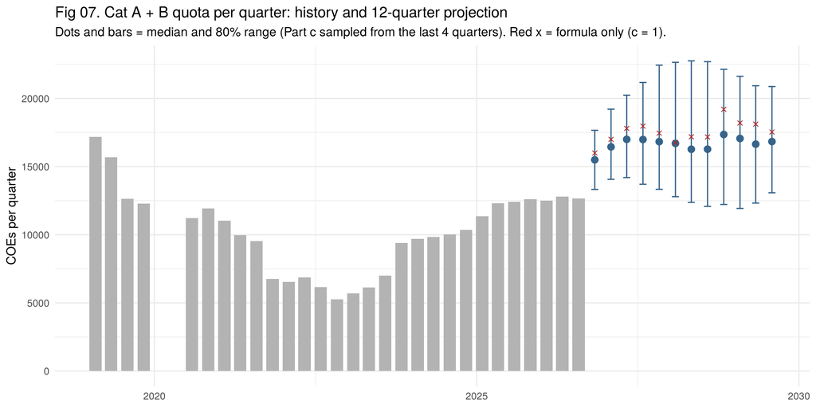

```r
write_csv(fan_q, file.path(OUT_DIR, "quota_fan_AB.csv"))
write_csv(fan_m, file.path(OUT_DIR, "dereg_fan_AB.csv"))

p07 <- ggplot(fan_q, aes(mi_date(qs))) +
  geom_col(data = quota_hist %>% filter(qs >= mi("2019-02")), aes(mi_date(qs), quota), fill = "grey70", width = 70) +
  geom_errorbar(aes(ymin = lo80, ymax = hi80), colour = "steelblue4", width = 40) +
  geom_point(aes(y = median), colour = "steelblue4", size = 2.5) +
  geom_point(aes(y = formula_only), shape = 4, colour = "firebrick") +
  labs(title = "Fig 07. Cat A + B quota per quarter: history and 12-quarter projection",
       subtitle = "Dots and bars = median and 80% range (Part c sampled from the last 4 quarters). Red x = formula only (c = 1).",
       x = NULL, y = "COEs per quarter") + theme_minimal()
save_plot(p07, "fig07_quota_fan.png")
```

**Observations (Fig 07). This is the headline chart for the deck.**

- Combined Cat A + B quota is projected to rise from about **12,700 a quarter now to about 15,500 for Nov 2026 - Jan 2027**, then to **16,000-17,500 a quarter through 2029**.
- The **80% range widens from about 13,300-17,700 next quarter to about 12,000-22,700 by 2028**. The lower end barely moves; the uncertainty is mostly on the upside.
- The red crosses (formula only, no top-ups) sit slightly above the median, because LTA’s recent adjustments have been below 1.
- **Live check:** LTA announces the Nov 2026 - Jan 2027 quota this month. Comparing it with the 13,300-17,700 range is a genuine out-of-sample test to present.
- **Why it matters:** this is the supply view dealers and fleets cannot get today: 12 quarters ahead, as a range. Because it is combined A + B, it remains valid if LTA merges the two categories.

### 9.3 Exposure (illustrative)

supply-driven part of premium risk only. Elasticity of premium to quota from quarter-on-quarter changes.

```r
prem_q <- results %>% filter(vehicle_class %in% c("Category A", "Category B")) %>%
  mutate(qs = t - ((t %% 12L) - 1L) %% 3L) %>% group_by(qs) %>%
  summarise(premium = mean(premium), .groups = "drop") %>% inner_join(quota_hist, by = "qs") %>%
  arrange(qs) %>% mutate(dlp = log(premium) - lag(log(premium)), dlq = log(quota) - lag(log(quota)))
el <- lm(dlp ~ dlq, prem_q)
beta <- coef(el)["dlq"]; beta_se <- summary(el)$coefficients["dlq", "Std. Error"]
cat(sprintf("\n9.3 Premium elasticity to quota: %.2f (SE %.2f), R2 %.2f. Demand is NOT modelled.\n",
            beta, beta_se, summary(el)$r.squared))
```

```
9.3 Premium elasticity to quota: -0.29 (SE 0.11), R2 0.14. Demand is NOT modelled.
```

**Observations (9.3).** This step is deliberately labelled illustrative.

- Quarter-on-quarter, a **1% rise in quota goes with a 0.29% fall in premium** (SE 0.11), but quota explains only 14% of premium movements. Demand, credit and policy drive the rest, which is why the project forecasts supply, not premiums.

```r
prem_now  <- results %>% filter(t == max(t), vehicle_class %in% c("Category A", "Category B")) %>% summarise(mean(premium)) %>% pull()
quota_now <- tail(quota_hist$quota, 1)                # latest complete quarter (Aug-Oct 2026)
betas <- rnorm(N_SIM, beta, beta_se)
prem_paths <- sapply(seq_len(N_SIM), function(s) prem_now * (QS[, s] / quota_now)^betas[s])   # quarters x sims
exposure <- map_dfr(0:2, function(shift) {
  cost <- colSums(prem_paths[(1:4) + shift, , drop = FALSE] * ORDER_BOOK)
  tibble(shift_quarters = shift, expected = mean(cost), p10 = quantile(cost, .1), p90 = quantile(cost, .9))
})
cat(sprintf("Order book: %s cars over 4 quarters, current premium S$%s\n", sum(ORDER_BOOK), comma(prem_now)))
```

```
Order book: 200 cars over 4 quarters, current premium S$130,050
```

```r
print(exposure %>% mutate(across(-shift_quarters, ~ comma(round(.x, -3)))))
```

```
# A tibble: 3 x 4
  shift_quarters expected   p10        p90
           <int> <chr>      <chr>      <chr>
1              0 24,052,000 22,494,000 25,418,000
2              1 23,872,000 22,111,000 25,448,000
3              2 23,848,000 21,826,000 25,628,000
```

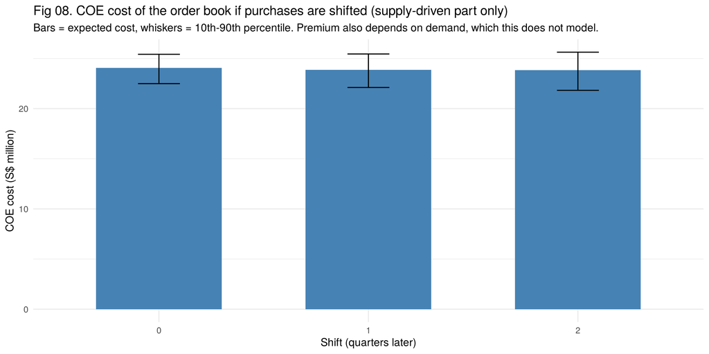

```r
write_csv(exposure, file.path(OUT_DIR, "exposure_by_shift.csv"))

p08 <- ggplot(exposure, aes(factor(shift_quarters), expected / 1e6)) +
  geom_col(fill = "steelblue", width = .6) +
  geom_errorbar(aes(ymin = p10 / 1e6, ymax = p90 / 1e6), width = .2) +
  labs(title = "Fig 08. COE cost of the order book if purchases are shifted (supply-driven part only)",
       subtitle = "Bars = expected cost, whiskers = 10th-90th percentile. Premium also depends on demand, which this does not model.",
       x = "Shift (quarters later)", y = "COE cost (S$ million)") + theme_minimal()
save_plot(p08, "fig08_exposure_shift.png")
```

**Observations (Fig 08).**

- For a dealer registering 200 cars over the next four quarters at today’s premium (S$130,050), the supply-driven expected COE cost is about **S$24.1 million, with an 80% range of S$22.5-25.4 million**.
- Shifting purchases one or two quarters later lowers the expected cost by only about **S$0.2 million (under 1%)**, while widening the range.
- **Why it matters:** the uncertainty (about S$3 million between the 10th and 90th percentiles) is about 15 times larger than anything timing saves. For a dealer guaranteeing package prices, **pricing in the risk band matters more than trying to time the market**. That is the case for a tool that shows the distribution, not a point estimate.

```r
cat("\nDone. Figures and CSVs in", OUT_DIR, "\n")
```

```
Done. Figures and CSVs in outputs
```

## 10. Summary for the report

**Business question.** Can COE supply be forecast far enough ahead, and with honest uncertainty, for a dealer or fleet operator to price and time real financial exposure?

**Answer: yes, for supply.**

1. **Supply is substantially mechanical.** Car deregistrations track COEs won exactly 10 years earlier (r = 0.88), and about 239,000 cars aged 7-10 will reach their 10-year decision between 2026 and 2029.
2. **A simple cohort model beats the existing approach.** Counting the cars coming due cuts forecast error by **39% (95% interval 23-55%)** compared with the rolling average quota.sg uses. The gain is largest 2-3 years ahead, the horizon businesses plan on.
3. **The forecast comes with an honest range.** Cat A + B quota is projected at about 15,500 next quarter and 16,000-17,500 a quarter through 2029, with an 80% range of roughly 12,000-22,700 by 2028. The ranges proved conservative on held-out data.
4. **The renewal feedback loop is real but small.** Higher PQP means fewer year-10 cars are scrapped, holding cohort size fixed, but it does not improve forecasts at current cohort sizes.
5. **For a dealer, risk outweighs timing.** On a 200-car order book, delaying purchases saves under 1%, while the uncertainty range spans about S$3 million.

**Limitations to state openly.**

- Age data are by vehicle type, so Cat A and Cat B are modelled together. That also makes the projection robust to the proposed A/B merger.
- LTA’s own adjustments (Part c) are policy, not mechanics; they are sampled from recent quarters, and they have fallen from about 1.3 to 0.84 within a year.
- Validation includes the COVID period, which makes the intervals conservative.
- Premiums are not forecast; the exposure step shows only the supply-driven part.

**Next steps.** Compare the Nov 2026 - Jan 2027 announcement with the projected range; test the lean model further, since it was best on the test period; and add monthly registrations so forecasts move smoothly within each year.